# Homework 3

Homework 3: Due Thursday 1-30-2024 at 11:59pm  
STAT 417: Survival Analysis Methods  
Name: Andrew Kerr

## 1. Hazard Functions

The following graphs are hazard functions for 4 distributions of $T$. For each one, sketch a possible corresponding cumulative hazard function $H(t)$. Be sure to label the same time points on your sketches as those provided on the graphs of $h(t)$. Notes: In graph (a) $h(t) = 0$ for $0 \leq t \leq 2$, and in graph (c), $h(t)$ is constant for $0 \leq t \leq 0.3$.

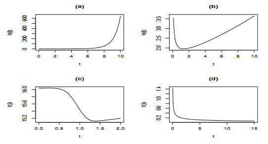

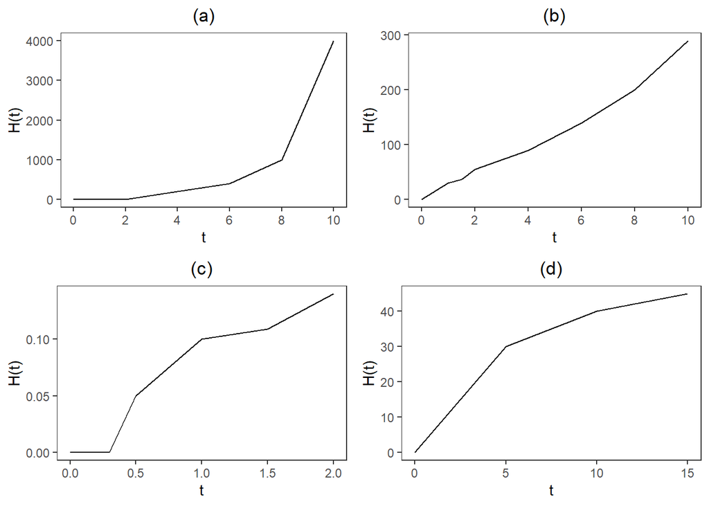

```r
cum_hazard_plot <- function(df, letter, force = F) {
  if(force) {
    ggplot(df) +
      geom_line(aes(x = t, y = cum_hazard)) +
      labs(
        title = letter,
        x = "t",
        y = "H(t)"
      ) +
      scale_x_continuous(breaks = seq(0, 10, 2)) +
      theme_bw() +
      theme(
        plot.title = element_text(hjust = 0.5),
        panel.grid = element_blank()
        )
  } else
    ggplot(df) +
      geom_line(aes(x = t, y = cum_hazard)) +
      labs(
        title = letter,
        x = "t",
        y = "H(t)"
      ) +
      theme_bw() +
      theme(
        plot.title = element_text(hjust = 0.5),
        panel.grid = element_blank()
        )
}

df_1 <- data.frame(
  t = c(0, 2, 4, 6, 8, 10),
  cum_hazard = c(0, 0, 200, 400, 1000, 4000)
  )

df_2 <- data.frame(
  t = c(0, 1, 1.5, 2, 4, 6, 8, 10),
  cum_hazard = c(0, 30, 37, 55, 90, 140, 200, 290)
  )

df_3 <- data.frame(
  t = c(0, 0.3, 0.5, 1, 1.5, 2),
  cum_hazard = c(0, 0, 0.05, 0.1, 0.109, 0.14)
  )

df_4 <- data.frame(
  t = c(0, 5, 10, 15),
  cum_hazard = c(0, 30, 40, 45)
  )

p_1 <- cum_hazard_plot(df_1, "(a)", T)
p_2 <- cum_hazard_plot(df_2, "(b)", T)
p_3 <- cum_hazard_plot(df_3, "(c)")
p_4 <- cum_hazard_plot(df_4, "(d)")

grid.arrange(p_1, p_2, p_3, p_4, ncol = 2, nrow = 2)
```

## 2. Cumulative Hazard Functions

The following graphs are cumulative hazard functions for 3 distributions of $T$. For each one, sketch a possible corresponding hazard function $h(t)$. Be sure to label the same time points on your sketches as those provided on the graphs of $H(t)$.

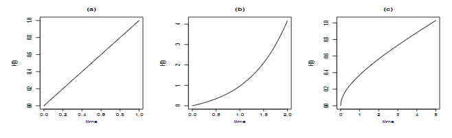

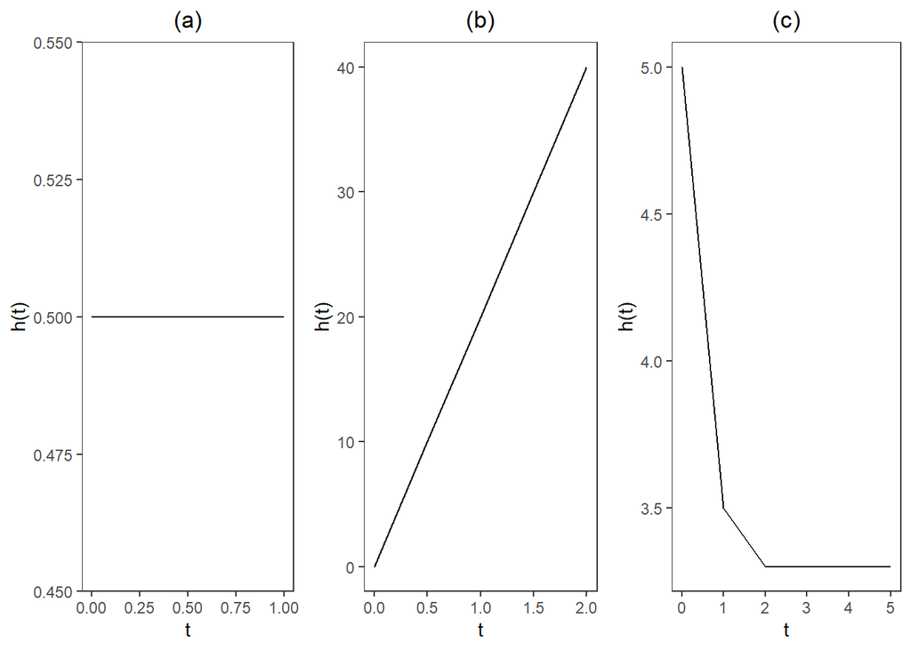

```r
hazard_plot <- function(df, letter) {
  ggplot(df) +
    geom_line(aes(x = t, y = cum_hazard)) +
    labs(
      title = letter,
      x = "t",
      y = "h(t)"
    ) +
    theme_bw() +
    theme(
      plot.title = element_text(hjust = 0.5),
      panel.grid = element_blank()
      )
}

df_1 <- data.frame(
  t = c(0, 0.2, 0.4, 0.6, 0.8, 1.0),
  cum_hazard = c(0.5, 0.5, 0.5, 0.5, 0.5, 0.5)
  )

df_2 <- data.frame(
  t = c(0, 0.5, 1.0, 1.5, 2.0),
  cum_hazard = c(0, 10, 20, 30, 40)
  )

df_3 <- data.frame(
  t = c(0, 1, 2, 3, 4, 5),
  cum_hazard = c(5, 3.5, 3.3, 3.3, 3.3, 3.3)
  )

p_1 <- hazard_plot(df_1, "(a)")
p_2 <- hazard_plot(df_2, "(b)")
p_3 <- hazard_plot(df_3, "(c)")

grid.arrange(p_1, p_2, p_3, ncol = 3, nrow = 1)
```

## 3. Exam Time Distribution

$$0.9, 0.8, 0.7, 0.9, 0.5, 0.7, 0.9, 0.9, 0.8, 0.6$$

1. Construct the likelihood function for $\theta$, i.e., find $L(\theta)$, simplifying as much as possible.

$$\begin{align*}
L(\theta) &= \prod_{1}^{10} f(t_i) \\
&= \prod_{1}^{10} (\theta + 1)t_i^\theta \\
&= (\theta + 1)^{10}\left[\prod_{1}^{10}t_i\right]^{\theta} \\
&= (\theta + 1)^{10} \cdot 0.0617^{\theta}
\end{align*}$$

2. Find the maximum likelihood estimate of $\theta$ for the given times.

$$\begin{align*}
l(\theta) &= ln[(\theta + 1)^{10}0.0617^{\theta}] = 10ln[\theta + 1] + \theta ln[0.0617] \\
l'(\theta) &= \frac{10}{\theta + 1} + ln[0.0617] = 0 \\
\hat{\theta} &\approx 2.59
\end{align*}$$

## 4. Weibull Distribution

Suppose a random sample $T_1, \dots, T_{10}$ is drawn from a Weibull distribution with $\beta = 2$ and $\lambda > 0$ (see notes for the expression of the Weibull pdf).

1. Construct the likelihood function for $\lambda$, i.e., find $L(\lambda)$, simplifying as much as possible.

$$\begin{align*}
L(\lambda) &= \prod_{1}^{10} f(t_i) \\
&= \prod_{1}^{10} \frac{\beta t_i^{\beta - 1}}{\lambda^\beta}exp[-(\frac{t_i}{\lambda})^\beta] \\
&= \prod_{1}^{10} \frac{2 t_i}{\lambda^2}exp[-(\frac{t_i}{\lambda})^2] \\
&= (\frac{2}{\lambda^2})^{10} \prod_{1}^{10}[t_i] \cdot exp[-\sum_1^{10}(\frac{t_i}{\lambda})^2] \\
&= (\frac{2}{\lambda^2})^{10} \prod_{1}^{10}t_i \cdot exp[-\frac{1}{\lambda^2} \sum_1^{10} t_i^2]
\end{align*}$$

2. Find the MLE for $\lambda$.

$$\begin{align*}
l(\lambda) &= ln[(\frac{2}{\lambda^2})^{10} \prod_{1}^{10}[t_i] \cdot exp[-\frac{1}{\lambda^2} \sum_1^{10} t_i^2] \\
&= 10ln(2) - 20ln(\lambda) + \sum_1^{10} ln(t_i) - \frac{1}{\lambda^2} \sum_1^{10} t_i^2 \\
l'(\lambda) &= -\frac{20}{\lambda} + \frac{2}{\lambda^3} \sum_1^{10} t_i^2 = 0 \\
\hat{\lambda} &= \sqrt{\frac{\sum_1^{10}t_i^2}{10}}
\end{align*}$$

## 5. Times to Relapse

The following data consists of the times to relapse of 12 bone marrow transplant patients. Suppose the time to relapse had an exponential distribution with parameter $\lambda$.

$$5, 8, 12, 24^+, 32, 17, 16, 17^+, 19^+, 21, 25, 30^+.$$

where the “$+$” denotes right-censored observations.

1. Construct the likelihood function for $\lambda$, simplifying as much as possible.

$$\begin{align*}
L(\lambda) &= \prod_{\text{complete times}} f(t_i) \cdot \prod_{\text{right censored times}} S(t_i) \\
&= \prod \frac{1}{\lambda}exp[\frac{-t_i}{\lambda}] \cdot exp[\frac{-t_i}{\lambda}] \\
&= \frac{1}{\lambda^8} exp[-\sum\frac{t_i}{\lambda}] \cdot exp[-\sum\frac{t_i}{\lambda}] \\
&= \frac{1}{\lambda^8}exp[-\frac{226}{\lambda}]
\end{align*}$$

2. Find the maximum likelihood estimate of $\lambda$ using the sample of observed survival times.

$$\begin{align*}
l(\lambda) &= ln[\frac{1}{\lambda^8}exp[-\frac{226}{\lambda}]] = -8ln(\lambda) - \frac{226}{\lambda} \\
l'(\lambda) &= \frac{-8}{\lambda} + \frac{226}{\lambda^2} = 0 \\
\hat{\lambda} &= \frac{226}{8} = 28.25
\end{align*}$$

## 6. Kaplan-Meier Estimation

The following times in minutes for 6 Cal Poly students to get ready in the morning are:

$$60, 12, 35, 30^+, 5, 20,$$

where the “$+$” denotes a right-censored time for a student who reported that they took at least 30 minutes.

1. Construct the Kaplan-Meier estimator for $S(t)$ using the observed times to get ready. Sketch a graph of the curve.

   | $i$ | Interval | $t_{(i)}$ | $n_i$ | $d_i$ | $n_i - d_i$ | $\hat{p_i}$ | $\hat{S}(t_{(i)})$ |
   | --- | --- | --- | --- | --- | --- | --- | --- |
   | 0 | [0, 5) | 0 | 6 | 0 | 6 | 1 | 1 |
   | 1 | [5, 12) | 5 | 6 | 1 | 5 | $\frac{5}{6}$ | $\frac{5}{6}$ |
   | 2 | [12, 20) | 12 | 5 | 1 | 4 | $\frac{4}{5}$ | $\frac{2}{3}$ |
   | 3 | [20, 35) | 20 | 4 | 1 | 3 | $\frac{3}{4}$ | $\frac{1}{2}$ |
   | 4 | [35, 60) | 35 | 2 | 1 | 1 | $\frac{1}{2}$ | $\frac{1}{4}$ |
   | 5 | [60, 60] | 60 | 1 | 1 | 0 | 0 | 0 |

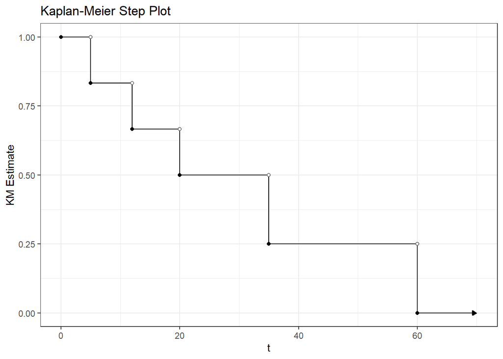

   ```r
   df <- data.frame(
     t = c(0, 5, 12, 20, 35, 60),
     km_est = c(1, 5/6, 2/3, 1/2, 1/4, 0)
     ) %>%
     mutate(lag_km_est = lag(km_est))


   ggplot(df) +
     geom_step(aes(x = t, y = km_est)) +
     geom_point(aes(x = t, y = km_est)) +
     geom_point(aes(x = t, y = lag_km_est), color = "white") +
     geom_point(aes(x = t, y = lag_km_est), shape = 1) +
     geom_segment(
       aes(x = 60, xend = 70, y = 0, yend = 0),
       arrow = arrow(type = "closed", length = unit(0.07, "inches"))
       ) +
     labs(title = "Kaplan-Meier Step Plot", x = "t", y = "KM Estimate") +
     theme_bw()
   ```

2. Using your answer to part (a), estimate the proportion of Cal Poly students who take longer than 30 minutes to get ready.

   P(T > 30) = $\hat{S}(30)$ = 0.5